# Population Scale Anlaysis [HW]

One sample is obviously not enough to know what is happening in a population. You are interested in assessing genetic differences on a population scale. So, you processed about ~230 samples and did the normalization on a genome level. Now, you want to find whether there is any association of the 4 asthma-associated SNPs **(rs8067378…)** on **ORMDL3** expression.

This is the final file you got (https://bioboot.github.io/bggn213_W19/class-material/rs8067378_ENSG00000172057.6.txt) The first column is sample name, the second column is genotype and the third column are the expression values.

Open a new RMarkdown document in RStudio to answer the following two questions. Submit your resulting PDF report with your working code, output and narrative text answering Q13 and Q14 to GradeScope.

## Q13: Read this file into R and determine the sample size for each genotype and their corresponding median expression levels for each of these genotypes.

```r
expr <- read.table('rs8067378_ENSG00000172057.6.txt')

head(expr)
```

```
##    sample geno      exp
## 1 HG00367  A/G 28.96038
## 2 NA20768  A/G 20.24449
## 3 HG00361  A/A 31.32628
## 4 HG00135  A/A 34.11169
## 5 NA18870  G/G 18.25141
## 6 NA11993  A/A 32.89721
```

```r
colnames(expr)
```

```
## [1] "sample" "geno"   "exp"
```

```r
nrow(expr)
```

```
## [1] 462
```

```r
table(expr$geno)
```

```
##
## A/A A/G G/G
## 108 233 121
```

**There are 462 samples within the data. Within the dataset there are 108 A/A, 233 A/G, and 121 G/G**

```r
library(dplyr)
```

Median expression levels

```r
median_aa <- expr %>%
  filter(geno == 'A/A') %>%
  summarise(median_aa = median(exp)) %>%
  pull(median_aa)

median_aa
```

```
## [1] 31.24847
```

```r
median_ag <- expr %>%
  filter(geno == 'A/G') %>%
  summarise(median_ag = median(exp)) %>%
  pull(median_ag)

median_ag
```

```
## [1] 25.06486
```

```r
median_gg <- expr %>%
  filter(geno == 'G/G') %>%
  summarise(median_gg = median(exp)) %>%
  pull(median_gg)

median_aa
```

```
## [1] 31.24847
```

## Q14: Generate a boxplot with a box per genotype, what could you infer from the relative expression value between A/A and G/G displayed in this plot? Does the SNP effect the expression of ORMDL3?

```r
library(ggplot2)
```

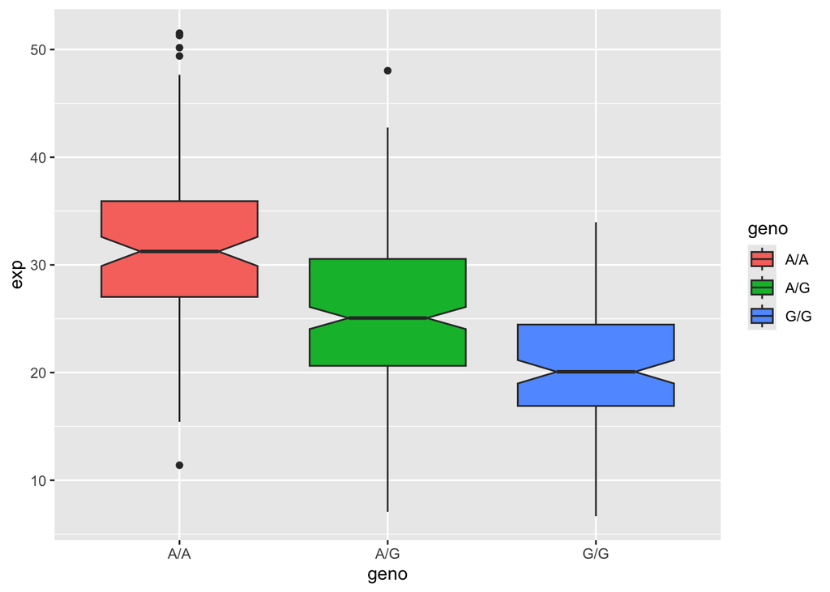

```r
ggplot(expr) +
  aes(x = geno,
      y = exp,
      fill = geno) +
  geom_boxplot(notch=T)
```

**Based on the boxplot we can see that when someone is homozygous for A (A/A), the expression levels are at a relatively high level as comapred to when someone is homoygous for G (G/G). Based on this inference we can tell that SNP does indeed effect the exoression of ORMLD3**